**Code in R for [Coursera-ML](https://www.coursera.org/learn/machine-learning) and [CMPUT466/551](https://www.ualberta.ca/computing-science/undergraduate-studies/course-directory/courses/machine-learning) in University of Alberta**

This post refers to programming exercise 1 in Coursera-ML. All the code can be found in [this repo](https://github.com/billy-inn/CourseraMLwithR).

```r
setwd("~/Coding/R/CMPUT466/mlclass-ex1")
library(ggplot2)
library(MASS)
```

### Linear regression with one variable

#### Plotting the Data

Use a scatter plot to visualize the data.

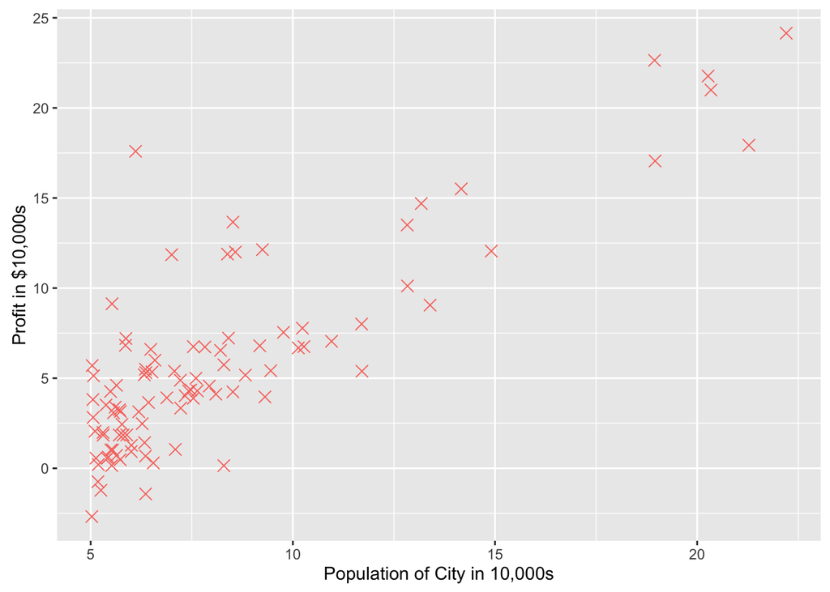

```r
data <- read.csv("ex1data1.txt", header=FALSE)
ggplot(data, aes(V1, V2, col="Training data")) +
  geom_point(shape=I(4), size=I(3)) +
  labs(x="Population of City in 10,000s", y="Profit in $10,000s") +
  scale_color_discrete(guide=FALSE)
```

#### Gradient Descent

Compute the cost function:

$$J(\theta)=\frac1{2m}\sum_{i=1}^m(h_\theta(x^{(i)})-y^{(i)})^2$$

where the hypothesis $h_\theta(x)$ is given by the linear model

$$h_{\theta)}(x)=\theta^T x$$

```r
computeCost = function(X, y, theta) {
  m = length(X)
  return(sum(((X %*% theta) - y)^2)/(2*m))
}

X <- as.matrix(data$V1)
X <- cbind(1, X)
y <- as.matrix(data$V2)
theta <- matrix(0, 2, 1)
computeCost(X, y, theta)
```

```
## [1] 16.03637
```

Use batch gradient descent algorithm to minimize cost function. In each iteration:

$$\theta_j = \theta_j - \alpha\frac1m\sum_{i=1}^m(h_\theta(x^{(i)}) - y^{(i)})x_j^{(i)}$$

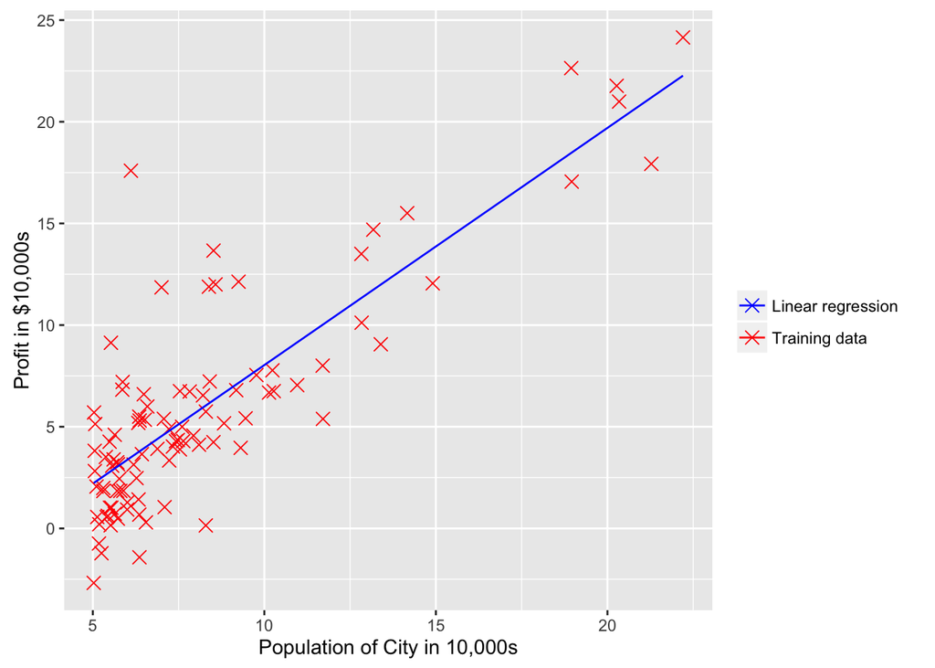

```r
iterations <- 1500
alpha <- 0.01
m <- length(y)
J_history <- matrix(0, iterations, 1)
for(i in 1:iterations) {
  theta <- theta - alpha/m*t(X) %*% (X %*% theta - y)
  J_history[i] <- computeCost(X, y, theta)
}

ggplot(data, aes(V1, V2, col="Training data")) +
  geom_point(shape=I(4), size=I(3)) +
  labs(x="Population of City in 10,000s", y="Profit in $10,000s") +
  geom_line(aes(X[,2], X %*% theta, col="Linear regression")) +
  scale_color_manual(name="", values=c("Blue", "Red"))
```

### Linear regression with multiple variables

#### Feature Normalization

When features differ by orders of magnitude, performing feature scaling can make gradient descent converge much more quickly. The `scale` function in R can be useful in this task.

```r
data <- read.csv("ex1data2.txt", header=FALSE)
X <- as.matrix(data[,c("V1", "V2")])
y <- as.matrix(data$V3)
m <- length(y)

X <- scale(X)
mu <- attr(X, "scaled:center")
sigma <- attr(X, "scaled:scale")

X <- cbind(1, X)
```

#### Gradient Descent

Computing the cost function and the gradient descent algorithm are similar to the univariate case. Four different learning rates are selected to see the rate of convergence.

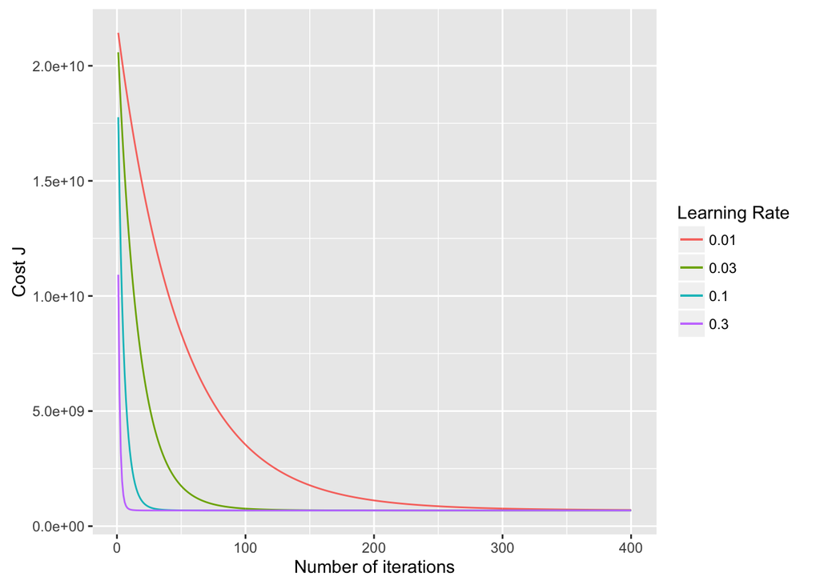

```r
alpha = c(0.01, 0.03, 0.1, 0.3)
num_iters = 400
theta = matrix(0, 3, 4)
J_history <- matrix(0, num_iters, 4)
for(i in 1:num_iters) {
  for(j in 1:4) {
  theta[,j] <- theta[,j] - alpha[j]/m*t(X) %*% (X %*% theta[,j] - y)
  J_history[i, j] <- computeCost(X, y, theta[,j])
  }
}

df <- data.frame(x=1:num_iters, y=J_history)
ggplot(df, aes(x)) + labs(x="Number of iterations", y="Cost J") +
  geom_line(aes(y=y.1, col="0.01")) +
  geom_line(aes(y=y.2, col="0.03")) +
  geom_line(aes(y=y.3, col="0.1")) +
  geom_line(aes(y=y.4, col="0.3")) +
  scale_color_discrete(name="Learning Rate")
```

Use $\theta$ that we’ve found to predict the price of a house with $1650$ square feet and 3 bedrooms. Remember to do the feature normalization first!

```r
X_predict <- (c(1650., 3.) - mu)/sigma
price <- c(1, X_predict) %*% theta
price
```

```
##          [,1]   [,2]     [,3]     [,4]
## [1,] 289314.6 293150 293081.5 293081.5
```

#### Normal Equations

The closed-form solution to linear regression is:

$$\theta=(X^T X)^{-1}X^T y$$

```r
data <- read.csv('ex1data2.txt', header=FALSE)
X <- as.matrix(data[, c("V1", "V2")])
y <- as.matrix(data$V3)
m <- length(y)

X <- cbind(1, X)

theta = ginv(t(X) %*% X, tol=0) %*% t(X) %*% y

price <- c(1, 1650, 3) %*% theta
price
```

```
##          [,1]
## [1,] 293081.5
```

The predicted price is almost the same as the price obtained using gradient descent.